# R: Anwendungsbeispiele

2024-12-13

## Netzwerkanalyse

## Netzwerke: Grundlagen

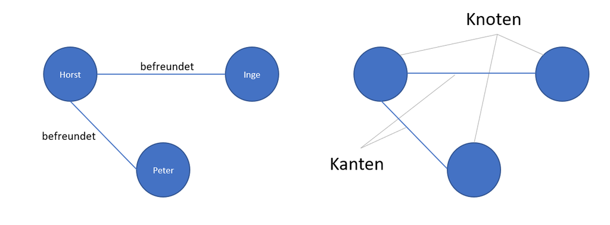

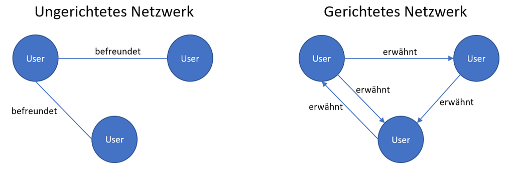

## Netzwerke: mono- und bipartit

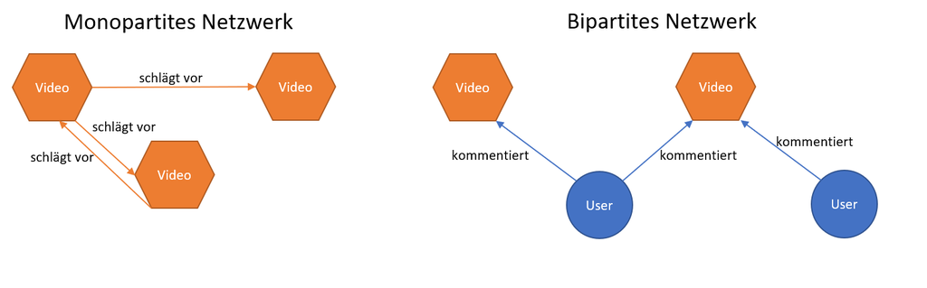

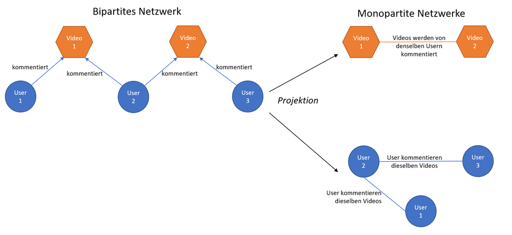

## Tools

- Häufig wird die *igraph* Library zur Netzwerkanalyse verwendet. Es gibt sie sowhohl in *R* als auch *Python*
- Alternative: *tidygraph*, eine an das *tidyverse* angegliederte Variante der Netzwerkanalyse
- Größtenteils Wrapper für *igraph*, welche die Manipulation von Netzwerkdaten mit *tidy*/*dplyr*-Syntax erlauben
- Visualisierung von Nertzwerken ist z.B. mit *ggraph* möglich, welches den Syntax von *ggplot2* übernimmt

## Beispieldaten

Kommentare zu von Parteien hochgeladenen Videos auf Youtube vom Januar 2022

```r
video_comments <- vroom("data/party_comments_january.csv.gz",
                        col_types = list(video_id = "c",
                                         comment_id = "c"))
```

## Beispieldaten

```r
str(video_comments)
```

```
spc_tbl_ [24,850 × 10] (S3: spec_tbl_df/tbl_df/tbl/data.frame)
 $ video_id           : chr [1:24850] "8aqEV5Sa4d4" "8aqEV5Sa4d4" "8aqEV5Sa4d4" "8aqEV5Sa4d4" ...
 $ video_PublishedAt  : POSIXct[1:24850], format: "2022-01-31 08:19:26" "2022-01-31 08:19:26" ...
 $ party              : chr [1:24850] "cdu" "cdu" "cdu" "cdu" ...
 $ party_label        : chr [1:24850] "CDU" "CDU" "CDU" "CDU" ...
 $ textDisplay        : chr [1:24850] "Seit 2015 unwählbar." "Ich würde mir mehr aktuelle Videos zur politischen Situation und zur klaren Haltung der CDU wünschen!!!! Und eb"| __truncated__ "Guten Morgen!!! sucht auch nach diesem Video:                                            THE ERRORS of GLOBALIS"| __truncated__ "Ahh ich muss es irgendwo raus lassen ..... Die Rede von F. Merz verkörpert warum ihr in der Zeit stehen geblieb"| __truncated__ ...
 $ textOriginal       : chr [1:24850] "Seit 2015 unwählbar." "Ich würde mir mehr aktuelle Videos zur politischen Situation und zur klaren Haltung der CDU wünschen!!!! Und eb"| __truncated__ "Guten Morgen!!! sucht auch nach diesem Video:                                            THE ERRORS of GLOBALIS"| __truncated__ "Ahh ich muss es irgendwo raus lassen ..... Die Rede von F. Merz verkörpert warum ihr in der Zeit stehen geblieb"| __truncated__ ...
 $ authorDisplayName  : chr [1:24850] "Hans Semlerek" "Jan Ehlers" "Dieter Kieltsch" "Gkingkameha jojo" ...
 $ likeCount          : num [1:24850] 0 0 1 1 0 0 0 0 0 0 ...
 $ comment_PublishedAt: POSIXct[1:24850], format: "2023-01-31 20:00:28" "2022-04-25 05:41:42" ...
 $ comment_id         : chr [1:24850] "Ugz6CF8jvP-MxljnOY54AaABAg" "UgzSubvx9o8kPITgaT94AaABAg" "Ugxtt79jkgXCsTwtETp4AaABAg" "Ugzo9v188qs3jTzHqA14AaABAg" ...
 - attr(*, "spec")=
  .. cols(
  ..   video_id = col_character(),
  ..   video_PublishedAt = col_datetime(format = ""),
  ..   party = col_character(),
  ..   party_label = col_character(),
  ..   textDisplay = col_character(),
  ..   textOriginal = col_character(),
  ..   authorDisplayName = col_character(),
  ..   likeCount = col_double(),
  ..   comment_PublishedAt = col_datetime(format = ""),
  ..   comment_id = col_character()
  .. )
 - attr(*, "problems")=<externalptr>
```

## *tidygraph*

```r
library(tidyverse)
library(igraph)
library(tidygraph)
library(ggraph)
```

Bipartiter Graph von User zu VideoID (wer hat was kommentiert?)

```r
comments_graph <- video_comments %>%
  # 3 Kommentare von Usern mit fehlendem Namen werden entfernt:
  filter(!is.na(authorDisplayName)) %>%
  # nur die Spalten authorDisplayName und Video ID auswählen:
  select(authorDisplayName, video_id) %>%
  # Umwandlung in einen Netzwerkgraphen:
  as_tbl_graph(directed = TRUE)
```

## *tidygraph*

```r
comments_graph
```

```
# A tbl_graph: 10437 nodes and 24847 edges
#
# A directed acyclic multigraph with 3 components
#
# Node Data: 10,437 × 1 (active)
   name
   <chr>
 1 Hans Semlerek
 2 Jan Ehlers
 3 Dieter Kieltsch
 4 Gkingkameha jojo
 5 DooWop Paradise
 6 fueled by mids
 7 Alfred Suhrbier
 8 Uwe Umbach
 9 Rutut b
10 BFC Dynamo
# ℹ 10,427 more rows
#
# Edge Data: 24,847 × 2
   from    to
  <int> <int>
1     1 10312
2     2 10312
3     3 10312
# ℹ 24,844 more rows
```

## Visualisierung

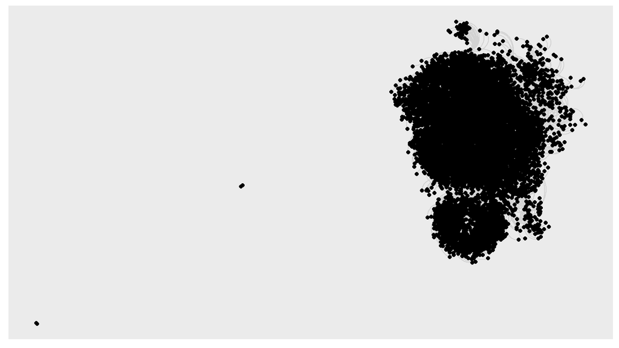

```r
ggraph(comments_graph,
       layout = "fr") + # Layout wählen
  geom_edge_arc(color = "lightgrey") + # Edges hinzufügen
  geom_node_point() # Nodes hinzufügen
```

## Manipulation des Graph

```r
comments_subgraph <- comments_graph %>%
  # Wir wollen auf den Nodes operieren, daher:
  activate(nodes) %>%
  # Wir berechnen den degree der Nodes:
  mutate(degree = centrality_degree(mode = "total")) %>%
  # Wir filtern nach Nodes, die einen Degree von mind. 3 haben:
  filter(degree >= 3)
```

## Vergleich mit igraph

```r
graph <- video_comments %>%
  filter(!is.na(authorDisplayName)) %>%
  select(authorDisplayName, video_id) %>%
  graph_from_data_frame()

# Berechnung des Degree
V(graph)$degree <- degree(graph, mode = "all")

# Filtern von Nodes mit Degree >= 3
subgraph <- induced_subgraph(graph,
                             vids = V(graph)[V(graph)$degree >= 3])
```

## Visualisierung II

```r
# Hinzufüges des Attributs "type",
#   welches zwischen Usern und Videos unterscheidet
comments_subgraph <- comments_subgraph %>%
  activate(nodes) %>%
  mutate(type = case_when((name %in%
                             video_comments$video_id) ~ "video",
                          (name %in%
                             video_comments$authorDisplayName) ~ "user"
  ))

ggraph(comments_subgraph, layout = "fr") +
  geom_edge_arc(color = "lightgrey") +
  geom_node_point(aes(color = type, # Typ als Farbe
                      size = degree)) + # degree als Größe
  theme_graph() # Ändern des Designs
```

## Visualisierung II

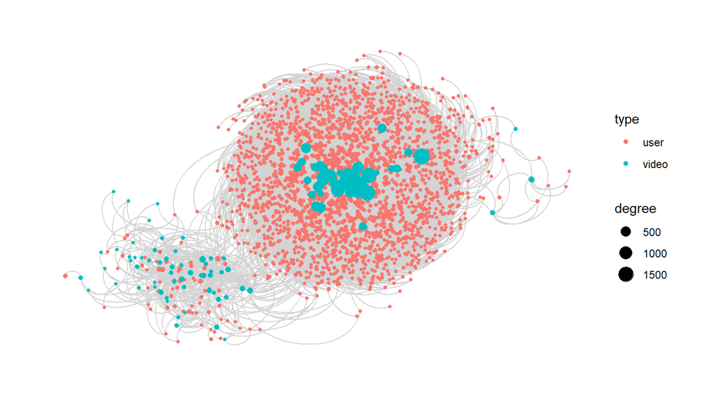

## Dynamische Netzwerke

```r
dynamic_data <- video_comments %>%
  # 3 Kommentare von Usern mit fehlendem Namen werden entfernt:
  filter(!is.na(authorDisplayName)) %>%
  # Hinzufügen eines Indikator für die Woche
  mutate(week = floor_date(video_PublishedAt, unit = "week"))
```

```r
graph_1 <- dynamic_data %>%
  filter(week == ymd("2022-01-02")) %>%
  select(authorDisplayName, video_id) %>%
  as_tbl_graph(directed = TRUE)

# ... und so weiter
```

**Problem:** langsam, viele einzelne Objekte

## Dynamische Netzwerke

**Lösung:** `map()` (parallelisierbar mit `future_map()`)

```r
dynamic_graphs <- dynamic_data %>%
  # Daten nach "week" in einzelne Dataframes aufteilen:
  group_by(week) %>%
  group_split() %>%
  # map nutzen, um über alle Dataframes zu operieren
  map(\(data) # "data" als platzhalter für den jeweiligen dataframe
      {
        data %>%
          select(authorDisplayName, video_id) %>%
          # Umwandlung in einen Netzwerkgraphen:
          as_tbl_graph(directed = TRUE) %>%
          # manipulieren des Graphs:
          activate(nodes) %>%
          mutate(degree = centrality_degree(mode = "total")) %>%
          mutate(type = case_when(
            (name %in%
               video_comments$video_id) ~ "video",
            (name %in%
               video_comments$authorDisplayName) ~ "user"
          ))})
```

*Ergebnis:* eine Liste mit Graphen für jede Woche

## Dynamische Netzwerke

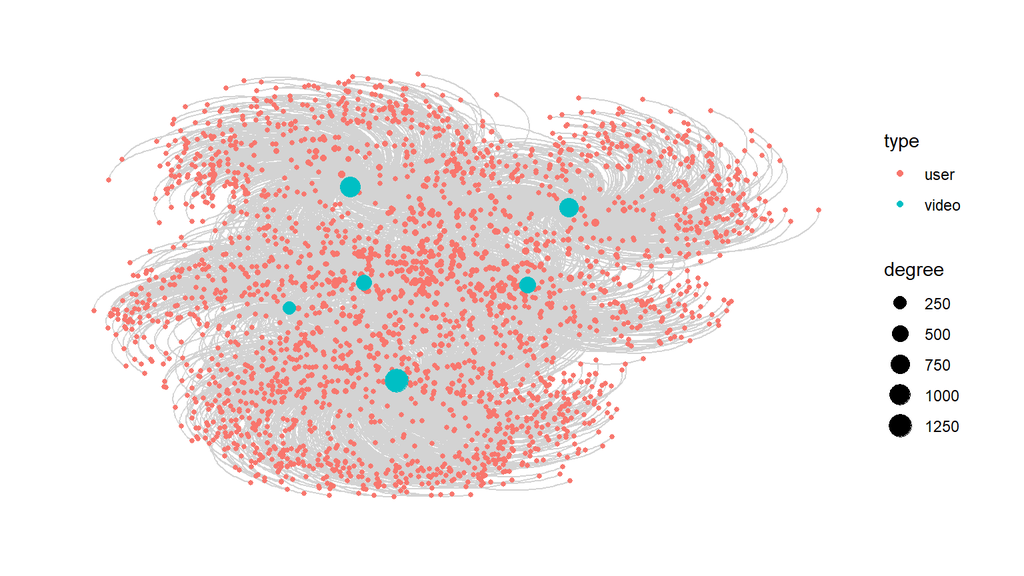

```r
ggraph(dynamic_graphs[[1]], # anwählen des 1. Graphen in der Liste
       layout = "fr") +
  geom_edge_arc(color = "lightgrey") +
  geom_node_point(aes(color = type, size = degree)) +
  theme_graph()
```

## Dynamische Netzwerke

Berechnung der Edge Density für jede Woche

```r
dynamic_graphs %>% map(\(graph) graph %>% edge_density)
```

```
[[1]]
[1] 0.0006741603

[[2]]
[1] 0.0005201064

[[3]]
[1] 0.0004839798

[[4]]
[1] 0.0005482104

[[5]]
[1] 0.0004285635
```

## Quantitative Textanalyse

## Quanteda

## Quanteda

- Framework zur quantitativen Textanalyse
- konsistente Handhabung von unterschiedlichen Datentypen wie Corpus, DFM, etc.
- schnell, da nativ parallelisiert
- erweiterte Funktionalitäten mit den Zusatzpaketen `quanteda.textstats` (Statistiken), `quanteda.textplots` (Visualisierung) und `quanteda.textmodels` (Textscaling & Classifier)
- nicht Teil des *tidyverse*, Syntax und Datentypen weichen ab
- Intro: https://quanteda.io/articles/quickstart.html

## Quanteda

```r
corpus <- corpus(video_comments %>%
                   # fehlende Kommentare entfernen:
                   filter(!is.na(comment_id)),
                 # Dokument ID definieren
                 docid_field = "comment_id",
                 # Text definieren
                 text_field = "textOriginal")

print(corpus)
```

```
Corpus consisting of 24,850 documents and 8 docvars.
Ugz6CF8jvP-MxljnOY54AaABAg :
"Seit 2015 unwählbar."

UgzSubvx9o8kPITgaT94AaABAg :
"Ich würde mir mehr aktuelle Videos zur politischen Situation..."

Ugxtt79jkgXCsTwtETp4AaABAg :
"Guten Morgen!!! sucht auch nach diesem Video:               ..."

Ugzo9v188qs3jTzHqA14AaABAg :
"Ahh ich muss es irgendwo raus lassen ..... Die Rede von F. M..."

UgwSgga3vqwbxtRP7qJ4AaABAg :
"Überbezahlte Nichtskönner !!! Haut ab .."

Ugw4HWqgQUxzJa6846B4AaABAg :
"..🙄😎🔪jenosse Landesveräter kriegtn neuen Haarschnitt..."

[ reached max_ndoc ... 24,844 more documents ]
```

## Quanteda

```r
tokens <- tokens(corpus,            # extract word tokens and remove punctuation
                 what = "word",
                 remove_punct = T)

print(tokens)
```

```
Tokens consisting of 24,850 documents and 8 docvars.
Ugz6CF8jvP-MxljnOY54AaABAg :
[1] "Seit"      "2015"      "unwählbar"

UgzSubvx9o8kPITgaT94AaABAg :
 [1] "Ich"         "würde"       "mir"         "mehr"        "aktuelle"
 [6] "Videos"      "zur"         "politischen" "Situation"   "und"
[11] "zur"         "klaren"
[ ... and 27 more ]

Ugxtt79jkgXCsTwtETp4AaABAg :
 [1] "Guten"     "Morgen"    "sucht"     "auch"      "nach"      "diesem"
 [7] "Video"     "THE"       "ERRORS"    "of"        "GLOBALISM" "Russia"
[ ... and 7 more ]

Ugzo9v188qs3jTzHqA14AaABAg :
 [1] "Ahh"      "ich"      "muss"     "es"       "irgendwo" "raus"
 [7] "lassen"   "Die"      "Rede"     "von"      "F"        "Merz"
[ ... and 70 more ]

UgwSgga3vqwbxtRP7qJ4AaABAg :
[1] "Überbezahlte" "Nichtskönner" "Haut"         "ab"

Ugw4HWqgQUxzJa6846B4AaABAg :
[1] "🙄"            "😎"            "🔪"            "jenosse"
[5] "Landesveräter" "kriegtn"       "neuen"         "Haarschnitt"

[ reached max_ndoc ... 24,844 more documents ]
```

## Quanteda

```r
dfm <- dfm(tokens,       # construct document-feature-matrix, all words to lower casing
           tolower = T) %>%
  dfm_remove(stopwords("german")) %>%  # remove german stopwords
  dfm_wordstem(language = "de")        # stem the words

print(dfm)
```

```
Document-feature matrix of: 24,850 documents, 30,605 features (99.97% sparse) and 8 docvars.
                            features
docs                         seit 2015 unwahlbar mehr aktuell videos polit
  Ugz6CF8jvP-MxljnOY54AaABAg    1    1         1    0       0      0     0
  UgzSubvx9o8kPITgaT94AaABAg    0    0         0    1       1      1     2
  Ugxtt79jkgXCsTwtETp4AaABAg    0    0         0    0       0      0     0
  Ugzo9v188qs3jTzHqA14AaABAg    0    0         0    1       0      0     0
  UgwSgga3vqwbxtRP7qJ4AaABAg    0    0         0    0       0      0     0
  Ugw4HWqgQUxzJa6846B4AaABAg    0    0         0    0       0      0     0
                            features
docs                         situation klar haltung
  Ugz6CF8jvP-MxljnOY54AaABAg         0    0       0
  UgzSubvx9o8kPITgaT94AaABAg         1    1       1
  Ugxtt79jkgXCsTwtETp4AaABAg         0    0       0
  Ugzo9v188qs3jTzHqA14AaABAg         0    0       0
  UgwSgga3vqwbxtRP7qJ4AaABAg         0    0       0
  Ugw4HWqgQUxzJa6846B4AaABAg         0    0       0
[ reached max_ndoc ... 24,844 more documents, reached max_nfeat ... 30,595 more features ]
```

## Top Tokens nach Partei

```r
dfm %>% textstat_frequency(groups = party_label) %>%
  group_by(group) %>% slice_max(docfreq, n = 2) %>%
  select(!rank)
```

```
# A tibble: 9 × 4
# Groups:   group [4]
  feature      frequency docfreq group
  <chr>            <dbl>   <dbl> <chr>
1 "afd"             4328    3687 AfD
2 "\U0001f44d"      5096    1955 AfD
3 "cdu"              260     195 CDU
4 "mensch"            79      76 CDU
5 "link"              66      55 DIE LINKE
6 "dass"              32      24 DIE LINKE
7 "mehr"              31      24 DIE LINKE
8 "uns"               30      19 SPD
9 "frau"              23      19 SPD
```

## Keywords in Context

Kontext für das Keyword “Deutschland”, nach Partei

```r
kwic_de <- tokens %>% tokens_group(party_label) %>% kwic("deutschland")
kwic_de %>%
  group_by(docname) %>%
  slice_sample(n = 2) %>%
  select(docname, pre, keyword, post)
```

```
# A tibble: 8 × 4
# Groups:   docname [4]
  docname   pre                                      keyword     post
  <chr>     <chr>                                    <chr>       <chr>
1 AfD       geschafft hätten der Welt wo             Deutschland ein Land der D…
2 AfD       wenigsten zu ihr schreihälse arme        Deutschland Die Großmäuler…
3 CDU       Holt wahrscheinlich halb Afrika nach     Deutschland Wg Vielfalt un…
4 CDU       Deren Hasssprech braucht niemand in      Deutschland Christlich Dem…
5 DIE LINKE funktionieren Bei einem Alleingang würde Deutschland wegen des derz…
6 DIE LINKE Viele Milliardäre nicht nur in           Deutschland haben ihre Ver…
7 SPD       auch dass die Mehrheit in                Deutschland geimpft ist wa…
8 SPD       setzt Das ist zu begrüßen                Deutschland setzt sich abe…
```

## Keyness

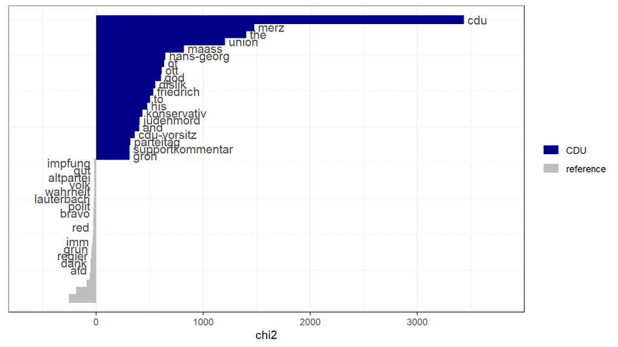

```r
dfm %>% dfm_group(party_label) %>%
  textstat_keyness(target = "CDU") %>%
  textplot_keyness()
```

## SpaCy

## spacyr

- Implementation des spaCy-Algorithmus in R (https://spacy.io/)
- Python Wrapper
- *spaCy* bietet vortrainierte Language Models für unterschiedliche Tasks
- gut für: parsing, lemmatization, Identifikation grammatikalischer Strukturen, Named Entity Recognition
- Integration mit Quanteda

## spacyr: Installation

Da es sich um einen *Python*-Wrapper handelt, benötigt *spacyr* eine *Python3*-Installation. *Diese ist auf dem Server vorhanden.* `spacy_install()` setzt eigenständig die benötigte *Python*-Umgebung auf. Da der Server Python 3.8 installiert hat, kann es sinnvoll sein, die zu installierende spaCy Version festzulegen, um Abhängigkeiten von späteren Python-Versionen zu vermeiden.

```r
library(spacyr)

spacy_install(version = "3.7.0")
```

## spacyr: Modelle

*spaCy* bietet unterschiedliche Modelle, welche jedoch erst heruntergeladen werden müssen. Eine Übersicht der Modelle findet sich hier: https://spacy.io/usage/models

```r
spacy_download_langmodel("de_core_news_sm")
```

Das gewählte Modell muss initialisiert werden, um es zu nutzen. `spacy_initialize()` startet den benötigten *Python*-Prozess im Hintergrund.

```r
spacy_initialize(model = "de_core_news_sm")
```

Nach der Verwendung sollte der *Python*-Prozess mit `spacy_finalize()` beendet werden:

```r
spacy_finalize()
```

## spacyr: Verwendung

Kernfunktion von *spacyr* ist `spacy_parse()`, welche mittels dem initialisierten Modell Text tokenisiert und Tokens klassifiziert. Darauf aufbauend bietet es unterschiedliche Funktionen:

- Named Entity Recognition mit `entity_extract()`
- Noun Phrase Recognition mit `nounphrase_extract()`
- Zusammenfügen häufig verwendeter Tokens zu einem Wort (z.B. Donald_Trump) mit `entity_consolidate()`
- Filterung nach unterschiedlichen Worttypen wie Zahlen oder Nomen

Für Beispiele siehe: https://spacyr.quanteda.io/articles/using_spacyr.html

## Structural Topic Modeling

## STM

- *R* Package *stm*
- Variante des Topic Modelling, basierend auf LDA
- Probabilistischer Prozess zur Zuordnung von Dokumenten und Wörtern zu latenten Themen, deren Anzahl im Voraus festgelegt werden muss
- erlaubt die Integration von zusätzlichen Variablen, etwa dem Veröffentlichungszeitpunkt eines Dokuments, und die Berechnung ihrer Effekte auf die Topic Prävalenz
- bietet zahlreiche Zusatzfunktionen für Diagnostik, Auswahl der Anzahl an Themen und Interpretation sowie Integration mit *Quanteda*
- https://www.structuraltopicmodel.com/

## STM: Anzahl Themen setzen

```r
out <- convert(dfm, to = "stm")
```

```r
Ks_prevalence <- searchK(documents = out$documents, vocab = out$vocab,
                         # für jedes K wird ein eigenes Modell berechnet
                         K = c(5:100),
                         prevalence = ~party, data = out$meta,
                         gamma.prior = "L1", init.type = "Spectral")
```

## STM: Anzahl Themen setzen

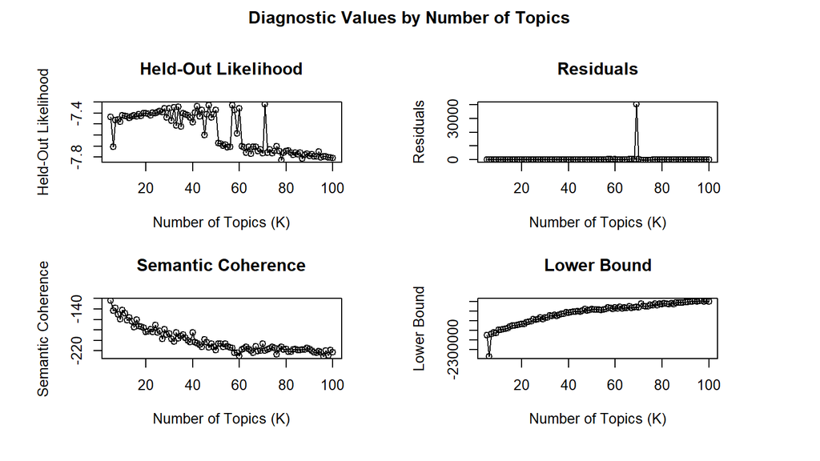

```r
plot.searchK(Ks_prevalence)
```

## STM: Anzahl Themen setzen

Faustregeln:

- Held-Out Likelihod und Semantische Koherenz maximieren
- Residuen minimieren
- Exclusivity beschreibt die Abgrenzbarkeit zwischen einzelnen Themen und sollte ggf. ebenfalls möglichst hoch sein
- häufiger Trade-Off zwischen semantischer Koherenz und Exklusivität
- Unterschiedliche Vorgehensweisen, z.B. Suche nach Plateaus - aber: abhängig von Textsorte und Anwendungsgebiet
- Evaluation sollte nicht nur statistisch, sondern auch im qualitativen Vergleich unterschiedlicher Modelle erfolgen

**Siehe auch:** Maier et al. 2018. Applying LDA Topic Modeling in Communication Research. https://doi.org/10.1080/19312458.2018.1430754.

## STM: Anzahl Themen setzen

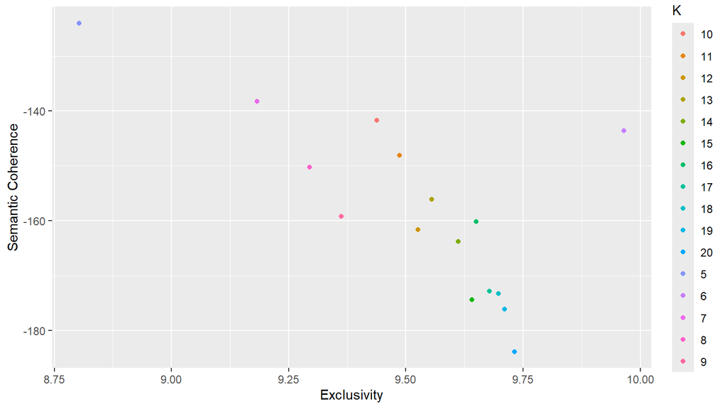

## Modell berechnen

```r
stm <- stm(documents = out$documents, vocab = out$vocab,
            K = 6,
            prevalence = ~party, data = out$meta,
            gamma.prior = "L1", init.type = "Spectral")
```

```r
summary(stm)
```

```
A topic model with 6 topics, 24783 documents and a 30562 word dictionary.
```

```
Topic 1 Top Words:
     Highest Prob: +, wahl, deutsch, frau, altpartei, dass, afd
     FREX: +, stimm, steuergeld, alic, patriot, antideutsch, gemeinsam
     Lift: @brazzo975, @edmond, @ein, @elisabeth, @fred, @gries, @harry
     Score: +, wahl, blodbarch, 🇬🇧, antideutsch, =, weidel
Topic 2 Top Words:
     Highest Prob: 💙, 🇩🇪, ❤, afd, 🤮, 🙏, 💪
     FREX: 💙, 🇩🇪, ❤, 🤮, 🙏, 💩, 😡
     Lift: 🖒, 🧙‍♀, 🧙‍♂, @merced, ✝, ❣, ⭐
     Score: 💙, 🇩🇪, ❤, 🙏, 🤮, forens, ✨
Topic 3 Top Words:
     Highest Prob: afd, dank, red, herr, partei, imm, 🤣
     FREX: herr, bravo, fdp, gott, toll, and, seid
     Lift: @michael, afdl, ausgesproch, bell, great, hamm, hock
     Score: red, bravo, dank, 🤣, herr, afd, the
Topic 4 Top Words:
     Highest Prob: 😂, jahr, neu, deutschland, corona, recht, 💥
     FREX: 😂, 💥, 🖕, 20, syst, 🥴, europa
     Lift: -test, @anett, @angelika, @carlisl, @ed, @friedrich, @goos
     Score: 😂, 💥, 🥴, 🐑, 🖕, rechtsprech, 👏🏼
Topic 5 Top Words:
     Highest Prob: polit, mehr, schon, ja, mal, mensch, regier
     FREX: lauterbach, leut, geh, arbeit, erst, selb, lasst
     Lift: ausserd, bloss, fallt, irgendwann, kurz, oben, spend
     Score: mal, polit, mehr, ja, geld, lauterbach, arbeit
Topic 6 Top Words:
     Highest Prob: 👍, 👏, gut, grun, deutschland, genau, wahrheit
     FREX: 👍, 👏, lug, ❗, habeck, baerbock, top
     Lift: ☆, 🇵🇱, andauernd, blindgang, brawo, dieb, elternteil
     Score: 👍, 👏, grun, gut, wahrheit, wort, ❗
```

## Modell evaluieren

```r
findThoughts(stm,
             texts = out$meta$textDisplay,
             n = 3)
```

```
 Topic 1:
     Idiokratie GERMANY<br><b>*********************</b><br>-<br>Ein gemerkeltes Schland in dem die DRITTSTÄRKSTE demokratisch gewählte Partei <br>von ALLEN ALTPARTEIEN ausgegrenzt und mehr oder weniger Offen GEHATED wird<br>und eine Beteiligung an der Regierung der AfD von denen verhindert wird die sich selbst <br>auf  &quot;DEMOKRATIE BERUFEN&quot; = Ist keine Demokratie !<br><br>Als die AfD 2013 in Sachsen 24,3 Prozent Stimmen bekam verunglimpften ALLE Altparteien<br>öffentlich alle AfD Wähler als &quot;Nicht demokratiefähige Populistenopfer&quot; und &quot;Hirnlose Protestwähler&quot;.<br>-<br>Anders ausgedrückt : &quot; Wir scheissen auf die Meinung eines Viertels der deutschen Bevölkerung !&quot;<br>Das nennen die Faschisten rund um die Zionistin Merkel dann &quot;Demokratie&quot;.<br>-<br>Die ANTIDEUTSCHE, ANTINATIONALE POLITIK der Merkel - Kabinette pflanzt sich <br>mit der Scholz / Blödbärchen / Lindner - Ampel fort  und das Armaggeddon der BRD <br>wird von COMPLETE BRAINWASHED, SLEEPING SHEEPS  noch fleissig beklatscht.<br>+<br>Es gibt Millionen von Merkelingen die dem Faschistensystem DANKBAR sind dass die <br>den Lockdown wieder geöffnet haben und die wieder ihre Verwandten und Nachbarn <br>BESUCHEN DÜRFEN  - oder nach 22.00 Uhr wieder aus dem Gaus dürfen !<br><br>ZWANGSQUARANTÄNE - VERSAMMLINGSVERBOTE - UNGEHORSAMSHAFT - <br>KONTAKTMELDEPFLICHT - IMPF-PFLICHT - NÄCHTLICHE AUSGANGSVERBOTE ???<br>Fehlt nur noch &quot;Schiessbefehl auf Ungehorsame Bürger&quot; = Dann haben wir &quot;Nordkorea 2 &quot;<br>-<br>Aber das wird von  Annalena Kim Pipppilotta Jong Blödbärchen Un - angestrebt<br>und bald werden die GRÜNEN NAZIS  hier weitere ANTIDEUTSCHE GESETZE installieren<br>und eine INVASIONSARMEE von Afromohammedanischen, Illiteralen Islamisten und<br>Kinderschändern wird die ANTIFA - Terrortruppe verstärken die dann im Auftrag der <br>Ampel - Diktatur mit Dienstmarken und Gewaltmonopol die BRD vollständig abfackelt !<br>-<br>++++++++++++++++++++++++++++++++++++++++++++++++++++++++++++++++++++++++++<br>-<br>Der Chef des BND und der des Verfassungsschutzes aber WARNTEN vor ein paar Wochen noch<br>Vor etwa 30.000 &quot;NEO NAZIS&quot; und Rechtsextremen , die derer Meinung nach &quot; DIE DERZEIT <br>GRÖSSTE GEFAHR&quot; für die &quot;Demokratie&quot; des &quot;Besten Deutschlands aller Zeiten&quot; darstellen !<br>+<br>Anders ausgedrückt : Denen geht der Arsch auf Grundeis vor :<br>QUERDENKERN, CORONA LEUGNERN, PEGIDA, Reichsbürgern, Q - Anon, <br>Identitären, Wutbürgern und vor der AfD und deren Wählern !<br>-<br>-<br>Eine STARKE, NATIONALE, PATRIOTISCHE FRONT - mit MUT ZU DEUTSCHLAND - Aber &quot;Normal&quot;<br>muss sich bilden die Gemeinsam Anarchie und Antideutsche in diesem Land bekämpfen.<br>Die AfD darf sich nicht weiter Spalten lassen oder in internen Grabenkämpfen verzetteln <br>und VERRÄTER und Opportunisten wie Meuthen - müssen unschädlich gemacht werden.<br>-<br>Dr. CURIO - das Verbale Panzergeschütz der AfD - trifft immer wieder PRÄZISE<br>die Gegner an deren Schwachstellen und BRANDNER = Das verbale Präzisionsgewehr <br>der AfD Fraktion erledigt die sauberen Headshots der Antideutschen im Parlament.<br>-<br>Wir Brauchen MEHR der AfD in der Regierung.<br><br>Dr. Alice Weidel = for Kanzlerette<br>Dr. Alexander Gauland = for Bundespräsident<br>Dr. Gotlieb Curio = for Innenminister<br>Stefan Brandner = for Justizminister<br><br><br>DEUTSCHE PATRIOTEN - WEHRT EUCH - Dieses ist UNSER LAND ! Unser HEIMATLAND.<br>Wir müssen es VERTEIDIGEN - sonst werden bald wir die &quot;refugees&quot; sein !<br><br>Keinen Meter Deutschland für Povertys und Asyltäuscher oder Islamisten !<br>-<br><br>WHITE LIFE MATTERS = 14 words !<br>+<br>+<br>+<br>Wayne / Januar 2022<br><b>*******************</b>
    Idiokratie GERMANY<br><b>*********************</b><br>-<br>Ein gemerkeltes Schland in dem die DRITTSTÄRKSTE demokratisch gewählte Partei <br>von ALLEN ALTPARTEIEN ausgegrenzt und mehr oder weniger Offen GEHATED wird<br>und eine Beteiligung an der Regierung der AfD von denen verhindert wird die sich selbst <br>auf  &quot;DEMOKRATIE BERUFEN&quot; = Ist keine Demokratie !<br><br>Als die AfD 2013 in Sachsen 24,3 Prozent Stimmen bekam verunglimpften ALLE Altparteien<br>öffentlich alle AfD Wähler als &quot;Nicht demokratiefähige Populistenopfer&quot; und &quot;Hirnlose Protestwähler&quot;.<br>-<br>Anders ausgedrückt : &quot; Wir scheissen auf die Meinung eines Viertels der deutschen Bevölkerung !&quot;<br>Das nennen die Faschisten rund um die Zionistin Merkel dann &quot;Demokratie&quot;.<br>-<br>Die ANTIDEUTSCHE, ANTINATIONALE POLITIK der Merkel - Kabinette pflanzt sich <br>mit der Scholz / Blödbärchen / Lindner - Ampel fort  und das Armaggeddon der BRD <br>wird von COMPLETE BRAINWASHED, SLEEPING SHEEPS  noch fleissig beklatscht.<br>+<br>Es gibt Millionen von Merkelingen die dem Faschistensystem DANKBAR sind dass die <br>den Lockdown wieder geöffnet haben und die wieder ihre Verwandten und Nachbarn <br>BESUCHEN DÜRFEN  - oder nach 22.00 Uhr wieder aus dem Gaus dürfen !<br><br>ZWANGSQUARANTÄNE - VERSAMMLINGSVERBOTE - UNGEHORSAMSHAFT - <br>KONTAKTMELDEPFLICHT - IMPF-PFLICHT - NÄCHTLICHE AUSGANGSVERBOTE ???<br>Fehlt nur noch &quot;Schiessbefehl auf Ungehorsame Bürger&quot; = Dann haben wir &quot;Nordkorea 2 &quot;<br>-<br>Aber das wird von  Annalena Kim Pipppilotta Jong Blödbärchen Un - angestrebt<br>und bald werden die GRÜNEN NAZIS  hier weitere ANTIDEUTSCHE GESETZE installieren<br>und eine INVASIONSARMEE von Afromohammedanischen, Illiteralen Islamisten und<br>Kinderschändern wird die ANTIFA - Terrortruppe verstärken die dann im Auftrag der <br>Ampel - Diktatur mit Dienstmarken und Gewaltmonopol die BRD vollständig abfackelt !<br>-<br>++++++++++++++++++++++++++++++++++++++++++++++++++++++++++++++++++++++++++<br>-<br>Der Chef des BND und der des Verfassungsschutzes aber WARNTEN vor ein paar Wochen noch<br>Vor etwa 30.000 &quot;NEO NAZIS&quot; und Rechtsextremen , die derer Meinung nach &quot; DIE DERZEIT <br>GRÖSSTE GEFAHR&quot; für die &quot;Demokratie&quot; des &quot;Besten Deutschlands aller Zeiten&quot; darstellen !<br>+<br>Anders ausgedrückt : Denen geht der Arsch auf Grundeis vor :<br>QUERDENKERN, CORONA LEUGNERN, PEGIDA, Reichsbürgern, Q - Anon, <br>Identitären, Wutbürgern und vor der AfD und deren Wählern !<br>-<br>-<br>Eine STARKE, NATIONALE, PATRIOTISCHE FRONT - mit MUT ZU DEUTSCHLAND - Aber &quot;Normal&quot;<br>muss sich bilden die Gemeinsam Anarchie und Antideutsche in diesem Land bekämpfen.<br>Die AfD darf sich nicht weiter Spalten lassen oder in internen Grabenkämpfen verzetteln <br>und VERRÄTER und Opportunisten wie Meuthen - müssen unschädlich gemacht werden.<br>-<br>Dr. CURIO - das Verbale Panzergeschütz der AfD - trifft immer wieder PRÄZISE<br>die Gegner an deren Schwachstellen und BRANDNER = Das verbale Präzisionsgewehr <br>der AfD Fraktion erledigt die sauberen Headshots der Antideutschen im Parlament.<br>-<br>Wir Brauchen MEHR der AfD in der Regierung.<br><br>Dr. Alice Weidel = for Kanzlerette<br>Dr. Alexander Gauland = for Bundespräsident<br>Dr. Gotlieb Curio = for Innenminister<br>Stefan Brandner = for Justizminister<br><br><br>DEUTSCHE PATRIOTEN - WEHRT EUCH - Dieses ist UNSER LAND ! Unser HEIMATLAND.<br>Wir müssen es VERTEIDIGEN - sonst werden bald wir die &quot;refugees&quot; sein !<br><br>Keinen Meter Deutschland für Povertys und Asyltäuscher oder Islamisten !<br>-<br><br>WHITE LIFE MATTERS = 14 words !<br>+<br>+<br>+<br>Wayne / Januar 2022<br><b>*******************</b>
    Idiokratie GERMANY<br><b>*********************</b><br>-<br>Ein gemerkeltes Schland in dem die DRITTSTÄRKSTE demokratisch gewählte Partei <br>von ALLEN ALTPARTEIEN ausgegrenzt und mehr oder weniger Offen GEHATED wird<br>und eine Beteiligung an der Regierung der AfD von denen verhindert wird die sich selbst <br>auf  &quot;DEMOKRATIE BERUFEN&quot; = Ist keine Demokratie !<br><br>Als die AfD 2013 in Sachsen 24,3 Prozent Stimmen bekam verunglimpften ALLE Altparteien<br>öffentlich alle AfD Wähler als &quot;Nicht demokratiefähige Populistenopfer&quot; und &quot;Hirnlose Protestwähler&quot;.<br>-<br>Anders ausgedrückt : &quot; Wir scheissen auf die Meinung eines Viertels der deutschen Bevölkerung !&quot;<br>Das nennen die Faschisten rund um die Zionistin Merkel dann &quot;Demokratie&quot;.<br>-<br>Die ANTIDEUTSCHE, ANTINATIONALE POLITIK der Merkel - Kabinette pflanzt sich <br>mit der Scholz / Blödbärchen / Lindner - Ampel fort  und das Armaggeddon der BRD <br>wird von COMPLETE BRAINWASHED, SLEEPING SHEEPS  noch fleissig beklatscht.<br>+<br>Es gibt Millionen von Merkelingen die dem Faschistensystem DANKBAR sind dass die <br>den Lockdown wieder geöffnet haben und die wieder ihre Verwandten und Nachbarn <br>BESUCHEN DÜRFEN  - oder nach 22.00 Uhr wieder aus dem Gaus dürfen !<br><br>ZWANGSQUARANTÄNE - VERSAMMLINGSVERBOTE - UNGEHORSAMSHAFT - <br>KONTAKTMELDEPFLICHT - IMPF-PFLICHT - NÄCHTLICHE AUSGANGSVERBOTE ???<br>Fehlt nur noch &quot;Schiessbefehl auf Ungehorsame Bürger&quot; = Dann haben wir &quot;Nordkorea 2 &quot;<br>-<br>Aber das wird von  Annalena Kim Pipppilotta Jong Blödbärchen Un - angestrebt<br>und bald werden die GRÜNEN NAZIS  hier weitere ANTIDEUTSCHE GESETZE installieren<br>und eine INVASIONSARMEE von Afromohammedanischen, Illiteralen Islamisten und<br>Kinderschändern wird die ANTIFA - Terrortruppe verstärken die dann im Auftrag der <br>Ampel - Diktatur mit Dienstmarken und Gewaltmonopol die BRD vollständig abfackelt !<br>-<br>++++++++++++++++++++++++++++++++++++++++++++++++++++++++++++++++++++++++++<br>-<br>Der Chef des BND und der des Verfassungsschutzes aber WARNTEN vor ein paar Wochen noch<br>Vor etwa 30.000 &quot;NEO NAZIS&quot; und Rechtsextremen , die derer Meinung nach &quot; DIE DERZEIT <br>GRÖSSTE GEFAHR&quot; für die &quot;Demokratie&quot; des &quot;Besten Deutschlands aller Zeiten&quot; darstellen !<br>+<br>Anders ausgedrückt : Denen geht der Arsch auf Grundeis vor :<br>QUERDENKERN, CORONA LEUGNERN, PEGIDA, Reichsbürgern, Q - Anon, <br>Identitären, Wutbürgern und vor der AfD und deren Wählern !<br>-<br>-<br>Eine STARKE, NATIONALE, PATRIOTISCHE FRONT - mit MUT ZU DEUTSCHLAND - Aber &quot;Normal&quot;<br>muss sich bilden die Gemeinsam Anarchie und Antideutsche in diesem Land bekämpfen.<br>Die AfD darf sich nicht weiter Spalten lassen oder in internen Grabenkämpfen verzetteln <br>und VERRÄTER und Opportunisten wie Meuthen - müssen unschädlich gemacht werden.<br>-<br>Dr. CURIO - das Verbale Panzergeschütz der AfD - trifft immer wieder PRÄZISE<br>die Gegner an deren Schwachstellen und BRANDNER = Das verbale Präzisionsgewehr <br>der AfD Fraktion erledigt die sauberen Headshots der Antideutschen im Parlament.<br>-<br>Wir Brauchen MEHR der AfD in der Regierung.<br><br>Dr. Alice Weidel = for Kanzlerette<br>Dr. Alexander Gauland = for Bundespräsident<br>Dr. Gotlieb Curio = for Innenminister<br>Stefan Brandner = for Justizminister<br><br><br>DEUTSCHE PATRIOTEN - WEHRT EUCH - Dieses ist UNSER LAND ! Unser HEIMATLAND.<br>Wir müssen es VERTEIDIGEN - sonst werden bald wir die &quot;refugees&quot; sein !<br><br>Keinen Meter Deutschland für Povertys und Asyltäuscher oder Islamisten !<br>-<br><br>WHITE LIFE MATTERS = 14 words !<br>+<br>+<br>+<br>Wayne / Januar 2022<br><b>*******************</b>
 Topic 2:
     AFD2022 Wirkt! Freiheit+Wohlstand 🇩🇪🇩🇪🇩🇪🇩🇪🇩🇪🇩🇪🇩🇪🇩🇪🇩🇪🇩🇪🇩🇪🇩🇪🇩🇪🇩🇪🇩🇪🇩🇪🇩🇪🇩🇪🇩🇪🇩🇪🇩🇪🇩🇪🇩🇪🇩🇪🇩🇪🇩🇪🇩🇪🇩🇪🇩🇪🇩🇪🇩🇪🇩🇪🇩🇪🇩🇪🇩🇪🇩🇪🇩🇪🇩🇪🇩🇪🇩🇪🇩🇪🇩🇪🇩🇪🇩🇪🇩🇪🇩🇪🇩🇪🇩🇪🇩🇪🇩🇪🇩🇪🇩🇪🇩🇪🇩🇪🇩🇪🇩🇪🇩🇪🇩🇪🇩🇪🇩🇪🇩🇪🇩🇪🇩🇪🇩🇪🇩🇪🇩🇪🇩🇪🇩🇪🇩🇪🇩🇪🇩🇪🇩🇪🇩🇪🇩🇪🇩🇪🇩🇪🇩🇪🇩🇪🇩🇪🇩🇪🇩🇪🇩🇪🇩🇪🇩🇪🇩🇪🇩🇪🇩🇪🇩🇪🇩🇪🇩🇪🇩🇪🇩🇪🇩🇪🇩🇪🇩🇪🇩🇪🇩🇪🇩🇪🇩🇪🇩🇪🇩🇪🇩🇪🇩🇪🇩🇪🇩🇪🇩🇪🇩🇪🇩🇪🇩🇪🇩🇪🇩🇪🇩🇪🇩🇪🇩🇪🇩🇪🇩🇪🇩🇪🇩🇪🇩🇪🇩🇪🇩🇪🇩🇪🇩🇪🇩🇪🇩🇪🇩🇪🇩🇪🇩🇪🇩🇪🇩🇪🇩🇪🇩🇪🇩🇪🇩🇪🇩🇪🇩🇪🇩🇪🇩🇪🇩🇪🇩🇪🇩🇪🇩🇪🇩🇪🇩🇪🇩🇪🇩🇪🇩🇪🇩🇪🇩🇪🇩🇪🇩🇪🇩🇪🇩🇪🇩🇪🇩🇪🇩🇪🇩🇪🇩🇪🇩🇪🇩🇪🇩🇪🇩🇪🇩🇪🇩🇪🇩🇪🇩🇪🇩🇪🇩🇪🇩🇪🇩🇪🇩🇪🇩🇪🇩🇪🇩🇪🇩🇪🇩🇪🇩🇪🇩🇪🇩🇪🇩🇪🇩🇪🇩🇪🇩🇪🇩🇪🇩🇪🇩🇪🇩🇪🇩🇪🇩🇪🇩🇪🇩🇪🇩🇪🇩🇪🇩🇪🇩🇪🇩🇪🇩🇪🇩🇪🇩🇪🇩🇪🇩🇪🇩🇪🇩🇪🇩🇪🇩🇪🇩🇪🇩🇪🇩🇪🇩🇪🇩🇪🇩🇪
    AFD2022 Wirkt! Freiheit statt Spaltung 🇩🇪🇩🇪🇩🇪🇩🇪🇩🇪🇩🇪🇩🇪🇩🇪🇩🇪🇩🇪🇩🇪🇩🇪🇩🇪🇩🇪🇩🇪🇩🇪🇩🇪🇩🇪🇩🇪🇩🇪🇩🇪🇩🇪🇩🇪🇩🇪🇩🇪🇩🇪🇩🇪🇩🇪🇩🇪🇩🇪🇩🇪🇩🇪🇩🇪🇩🇪🇩🇪🇩🇪🇩🇪🇩🇪🇩🇪🇩🇪🇩🇪🇩🇪🇩🇪🇩🇪🇩🇪🇩🇪🇩🇪🇩🇪🇩🇪🇩🇪🇩🇪🇩🇪🇩🇪🇩🇪🇩🇪🇩🇪🇩🇪🇩🇪🇩🇪🇩🇪🇩🇪🇩🇪🇩🇪🇩🇪🇩🇪🇩🇪🇩🇪🇩🇪🇩🇪🇩🇪🇩🇪🇩🇪🇩🇪🇩🇪🇩🇪🇩🇪🇩🇪🇩🇪🇩🇪🇩🇪🇩🇪🇩🇪🇩🇪🇩🇪🇩🇪🇩🇪🇩🇪🇩🇪🇩🇪🇩🇪🇩🇪🇩🇪🇩🇪🇩🇪🇩🇪🇩🇪🇩🇪🇩🇪🇩🇪🇩🇪🇩🇪🇩🇪🇩🇪🇩🇪🇩🇪🇩🇪🇩🇪🇩🇪🇩🇪🇩🇪🇩🇪🇩🇪🇩🇪🇩🇪🇩🇪🇩🇪🇩🇪🇩🇪🇩🇪🇩🇪🇩🇪🇩🇪🇩🇪🇩🇪🇩🇪🇩🇪
```

```
    ❤❤❤❤❤❤❤❤❤❤❤❤❤❤❤❤❤❤❤❤❤❤❤❤❤❤❤❤❤❤❤❤❤❤❤❤❤❤❤❤❤❤❤❤❤❤❤❤❤❤❤❤❤❤💙💙💙💙💙💙💙💙💙💙💙💙💙💙💙💙💙💙💙💙💙
 Topic 3:
     Jesus commes    and this is how He looks like in your heart: Revelation 1 13 like a son of man, clothed with a long robe and with a golden sash around his chest. 14 The hairs of his head were white, like white wool, like snow. His eyes were like a flame of fire, 15 his feet were like burnished bronze, refined in a furnace, and his voice was like the roar of many waters. 16 In his right hand he held seven stars, from his mouth came a sharp two-edged sword, and his face was like the sun shining in full strength.  ( each time you look on Him and give Him a bigger size as universes as He is much bigger than all created things it gets hotter because of more light.) He forgave us 2000 years ago even future sins.( Israel had a goat to free for 1 year future sins so how much more worth is the blood of God.).   Muslems, Jews and Christians awaits Jesus( no one awaits Paul or Muhammad to comme from heaven for us)  In the begginning was the Word and it is the true God.( without the word was nothing made.. word like by computer. God gave earth to humans and humans gave earth to devil so God became flesh to redeem humanity while dying on cross and ressurrecting on third day as a firstfruit so we can becomme like Him God in flesh. (because of this we count time BC (before Christ) and AC (after Christ)  or AD which is same  .: (under important playlist you find good teachings of others on my channel). Blessings dears and head up. ( God chose to not remember sins as far East is from WEST!! His armor is: His salvaion, His righteousness, His truth, His peace, His faith, His (s)word
<br>(ya take also His oil, waters, blood , winds, fire, crowns, light etc.  2Kor 3,18 And we all, with unveiled face, beholding the glory of the Lord, are being transformed into the same image from one degree of glory to another. For this comes from the Lord who is the Spirit.
    God did all what man was supposed to do --- God is not holding a sinner acountable for sin anymore but just for unbeleive in the redemptive work of Christ. God didnt died for the Church... God died for the world and when God sees us even in the very act of sin than He sees His work done on cross and not sin.
<br>God is very happy if we can just beleive because religion has messed us up. ( 2 Corinthians 5 18 All this is from God, who through Christ reconciled us to himself and gave us the ministry of reconciliation;19 that is, in Christ God was reconciling[3] the world to himself, not counting their trespasses against them, and entrusting to us the message of reconciliation. (when people say I will confess my sin and reconcile me back to God.. what are you talking?? we are not doing comedy we are talking of serious matters. bc we have nothing to offer what is worthy to apeasing of what we had done ... so God reconciled man to himself. settled all what man had supposed to settle and gave man an offer to receive the forgivness God has provided. (we are not reconciled through our contribution we are reconciled through JESUS CHRIST and HE has given us the ministry of reconciliation.
<br>God loves the world says Jon (Church would love if it where written church to put a barier between God and the world.
<br>..in other words  God is not holding a sinner accountable for sin.
<br>He didnt said not imputing the trespasses of the Church God said He is not imputing /holding accountable the trespasses of the WORLD.
<br>and now it is up to us to tell that to people because God entrusted us with that........is that so hard?..
    the slave owner was sin and death. death was the second slave owner and since we got Jesus sin was payed and death was payed and lost its ownership. so why than do people die? because we live in an mortal falen body and corruption must dress incorrupion. 1.Peter 1,23 Being born again, not of corruptible seed, but of incorruptible, by the word of God, which liveth and abideth for ever. 1Kor 15,52 In a moment, in the twinkling of an eye, at the last trump: for the trumpet shall sound, and the dead shall be raised incorruptible, and we shall be changed. 1Petr 1,4 To an inheritance incorruptible, and undefiled, and that fadeth not away, reserved in heaven for you, 1Kor 9,25 And every man that striveth for the mastery is temperate in all things. Now they do it to obtain a corruptible crown; but we an incorruptible. Röm 6,23 For the wages of sin is death; but the gift of God is eternal life through Jesus Christ our Lord.
 Topic 4:
     Die Willkür greift um sich..., egal in der kleinsten Ortschaft bis zur Hauptstadt Berlin, alles ist System Mafia. Selbst der BGH alle weiteren Gerichte sollten von der Forensik in die Zange genommen werden, so lange diese nicht in dieses System mit infiltriert wurde. Denn selbst das Militär/Soldaten werden in Polizei-Uniformen gesteckt ab dem G 20 Gipfel in der HH. So tief ist der Virus eingedrungen, extremer als dasssssss Coronavirus. 👎🤜🤛✌️👉💥<br> Es sind 200.000.000  Impfdosen bestellt...., nur mit einem Wirkungsgrad von 35 % , das Labor des Militärs in den USA einen neuen Impfstoff mit einem Wirkungsgrad über 85%. Wie viele Euro,s jetzt wieder verbrannt sind...😁😉 , sieh wie vieles andere mehr noch... Ohne Impfpflicht die Dosen nicht an die Bevölkerung gebracht werden kann...?🤝🤜🤛👎.  Der Verfolgungswahn Wahnsinn Endet nicht mal an einem PKW. Denn unter der Landesplakette ist ein Chip verdeckt geklebt (man kann es mit dem Finger spüren) und mit Infrarot gelesen (das es keiner sehen kann) werden kann um Bewegung&#39;s Profile und viel mehr zu erstellen eines PKW und dessen Eigentümer. Bei so gut allen neuen Kfz Kennzeichen. Ich habe es schon Deaktiviert. Man wird bei der Zulassungsstelle nicht darüber Informiert.. 🖕🖕🖕🤝😇 Diesen dummen Spruch, dass alle Daten gelöscht werden 🖕🖕🖕. Das geht gar nicht, da sonst auch immer alle Festplatten vernichtet werden müssen. So führen Sie Euch alle hinter das Licht. 👉👎😉 Mein Stiefvater Vater war beim BND in Köln Beschäftigt. 😉😏🤔🤔🤔🤔🤝🤝🤝🤝
    Die Willkür greift um sich..., egal in der kleinsten Ortschaft bis zur Hauptstadt Berlin, alles ist System Mafia. Selbst der BGH alle weiteren Gerichte sollten von der Forensik in die Zange genommen werden, so lange diese nicht in dieses System mit infiltriert wurde. Denn selbst das Militär/Soldaten werden in Polizei-Uniformen gesteckt ab dem G 20 Gipfel in der HH. So tief ist der Virus eingedrungen, extremer als dasssssss Coronavirus. 👎🤜🤛✌️👉💥<br> Es sind 200.000.000  Impfdosen bestellt...., nur mit einem Wirkungsgrad von 35 % , das Labor des Militärs in den USA einen neuen Impfstoff mit einem Wirkungsgrad über 85%. Wie viele Euro,s jetzt wieder verbrannt sind...😁😉 , sieh wie vieles andere mehr noch... Ohne Impfpflicht die Dosen nicht an die Bevölkerung gebracht werden kann...?🤝🤜🤛👎.  Der Verfolgungswahn Wahnsinn Endet nicht mal an einem PKW. Denn unter der Landesplakette ist ein Chip verdeckt geklebt (man kann es mit dem Finger spüren) und mit Infrarot gelesen (das es keiner sehen kann) werden kann um Bewegung&#39;s Profile und viel mehr zu erstellen eines PKW und dessen Eigentümer. Bei so gut allen neuen Kfz Kennzeichen. Ich habe es schon Deaktiviert. Man wird bei der Zulassungsstelle nicht darüber Informiert.. 🖕🖕🖕🤝😇 Diesen dummen Spruch, dass alle Daten gelöscht werden 🖕🖕🖕. Das geht gar nicht, da sonst auch immer alle Festplatten vernichtet werden müssen. So führen Sie Euch alle hinter das Licht. 👉👎😉 Mein Stiefvater Vater war beim BND in Köln Beschäftigt. 😉😏🤔🤔🤔🤔🤝🤝🤝🤝
    Die Willkür greift um sich..., egal in der kleinsten Ortschaft bis zur Hauptstadt Berlin, alles ist System Mafia. Selbst der BGH alle weiteren Gerichte sollten von der Forensik in die Zange genommen werden, so lange diese nicht in dieses System mit infiltriert wurde. Denn selbst das Militär/Soldaten werden in Polizei-Uniformen gesteckt ab dem G 20 Gipfel in der HH. So tief ist der Virus eingedrungen, extremer als dasssssss Coronavirus. 👎🤜🤛✌️👉💥<br> Es sind 200.000.000  Impfdosen bestellt...., nur mit einem Wirkungsgrad von 35 % , das Labor des Militärs in den USA einen neuen Impfstoff mit einem Wirkungsgrad über 85%. Wie viele Euro,s jetzt wieder verbrannt sind...😁😉 , sieh wie vieles andere mehr noch... Ohne Impfpflicht die Dosen nicht an die Bevölkerung gebracht werden kann...?🤝🤜🤛👎.  Der Verfolgungswahn Wahnsinn Endet nicht mal an einem PKW. Denn unter der Landesplakette ist ein Chip verdeckt geklebt (man kann es mit dem Finger spüren) und mit Infrarot gelesen (das es keiner sehen kann) werden kann um Bewegung&#39;s Profile und viel mehr zu erstellen eines PKW und dessen Eigentümer. Bei so gut allen neuen Kfz Kennzeichen. Ich habe es schon Deaktiviert. Man wird bei der Zulassungsstelle nicht darüber Informiert.. 🖕🖕🖕🤝😇 Diesen dummen Spruch, dass alle Daten gelöscht werden 🖕🖕🖕. Das geht gar nicht, da sonst auch immer alle Festplatten vernichtet werden müssen. So führen Sie Euch alle hinter das Licht. 👉👎😉 Mein Stiefvater Vater war beim BND in Köln Beschäftigt. 😉😏🤔🤔🤔🤔🤝🤝🤝
 Topic 5:
     Und solche Typen, die nicht wissen, wie teuer das Leben ist, die nie gearbeitet haben, legen fest, dass Kumpel, Gießer. alle Leute die Schwerstarbeit leisten...bis demnächst 67 Jahre arbeiten sollen...bis 67!! Es ist in vielen Berufen unmöglich, ab einem bestimmtem Alter noch solche Leistungen zu bringen. Die Knochen sind einfach kaputt! Woher kommt der politische Schwachsinn?? Die Rentenkassen sind leer...wir Arbeiter/ Rentenbezieher leben zu lange...oder kommt das von den vielen Griffen in die Rentenkassen...für Leute, die NIE eingezahlt haben und nun gepampert werden? Schickt die Politiker an die Basis , dort sollen sie den Leuten erklären, wo das Geld bleibt !
    Da braucht man keine Experten um zu wissen ob eine Impfpflicht nötig ist. Das kann jeder selber, mit ein bisschen lesen, selber herausfinden.<br>Viel wichtiger als eine Impfpflicht ist eine Regierung die nicht von Lobbyisten gelenkt wird sonder für das Wohl des Volkes regiert.<br>Wann ist eine Impfung eine Impfung? Eine Impfung ist eine Impfung wenn diese mich vor einer Ansteckung und vor der Verbreitung schützt. Alles andere ist Habgier des Herstellers und den Beteilgten bei der Verbreitung des &quot;Impfstoffes&quot;
    @Chrichri nein sind Sie nicht. Auch Ich bin gesundheitlich davon sehr angeschlagen, von Herzrasen, Hörsturz, Tinnitus und und und. Langsam versuche Ich wieder in die Ruhe zu kommen, was in meinem Job nicht immer einfach ist. Aber Ich stelle langsam fest, das es mehr Menschen gibt, die das ganze nicht mehr mitmachen wollen. Man kommt durchaus auch wieder mit klar denkenden Menschen in Kontakt. Daher heißt es durchhalten und sich nicht einschüchtern lassen und Gleichgesinnte finden
 Topic 6:
     👏👏👏👏👏👏👏👏👏👏👏👏👏👏👏👏👏👏👏👏👏👏👏👏👏👏👏👏👏👏👏👏👏👏👏👏👏👏👏👏👏👏👏👏👏👏👏👏👏👏👏👏👏👏👏👏👏👏👏👏👏👏👏👏👏👏👏👏👏👏👏👏👏👏👏👏👏👏👏👏👏👏👏👏👏👏👏👏👏👏👏👏👏👏👏👏👏👏👏👏👏👏👏👏👏👏👏👏👏👏👏👏👏👏👏👏👏👏👏👏👏👏👏👏👏👏👏👏👏👏👏👏👏👏👏👏👏👏👏👏👏👏.
    👏👏👏👏👏👏👏👏👏👏👏👏👏👏👏👏👏👏👏👏👏👏👏👏👏👏👏👏👏👏👏👏👏👏👏👏👏👏👏👏👏👏👏👏👏👏👏👏👏👏👏👏👏👏👏👏👏👏👏👏👏👏👏👏👏👏👏👏👏👏👏👏👏👏👏👏👏👏👏👏👏👏👏👏👏👏👏👏👏👏👏👏👏👏👏👏👏👏👏👏👏👏👏👏👏👏👏👏👏👏👏👏👏👏👏👏👏👏👏👏👏👏👏👏👏👏👏👏👏👏👏👏👏👏👏👏👏.
    👍👍👍👍👍👍👍👍👍👍👍👍👍👍👍👍👍👍👍👍👍👍👍👍👍👍👍👍👍👍👍👍👍👍👍👍👍👍👍👍👍👍👍👍👍
```

## Effekte der Metavariable Partei auf Themenprävalenz

```r
effects <- estimateEffect(~party, stmobj = stm, metadata = out$meta)

summary(effects)
```

```
Call:
estimateEffect(formula = ~party, stmobj = stm, metadata = out$meta)


Topic 1:

Coefficients:
             Estimate Std. Error t value Pr(>|t|)
(Intercept)  0.117488   0.001156 101.649  < 2e-16 ***
partycdu    -0.002489   0.006161  -0.404    0.686
partylinke   0.055593   0.013230   4.202 2.65e-05 ***
partyspd    -0.008166   0.014869  -0.549    0.583
---
Signif. codes:  0 '***' 0.001 '**' 0.01 '*' 0.05 '.' 0.1 ' ' 1


Topic 2:

Coefficients:
             Estimate Std. Error t value Pr(>|t|)
(Intercept)  0.129597   0.001644  78.852  < 2e-16 ***
partycdu    -0.030195   0.008223  -3.672 0.000241 ***
partylinke  -0.073784   0.015385  -4.796 1.63e-06 ***
partyspd    -0.090592   0.019999  -4.530 5.93e-06 ***
---
Signif. codes:  0 '***' 0.001 '**' 0.01 '*' 0.05 '.' 0.1 ' ' 1


Topic 3:

Coefficients:
             Estimate Std. Error t value Pr(>|t|)
(Intercept)  0.187150   0.001304 143.571  < 2e-16 ***
partycdu     0.038469   0.007524   5.113  3.2e-07 ***
partylinke   0.016669   0.015626   1.067  0.28610
partyspd    -0.051956   0.019795  -2.625  0.00868 **
---
Signif. codes:  0 '***' 0.001 '**' 0.01 '*' 0.05 '.' 0.1 ' ' 1


Topic 4:

Coefficients:
            Estimate Std. Error t value Pr(>|t|)
(Intercept) 0.139009   0.001368 101.601  < 2e-16 ***
partycdu    0.051398   0.009192   5.591 2.28e-08 ***
partylinke  0.042834   0.017600   2.434    0.015 *
partyspd    0.243055   0.026550   9.155  < 2e-16 ***
---
Signif. codes:  0 '***' 0.001 '**' 0.01 '*' 0.05 '.' 0.1 ' ' 1


Topic 5:

Coefficients:
             Estimate Std. Error t value Pr(>|t|)
(Intercept)  0.308105   0.001530 201.356   <2e-16 ***
partycdu     0.015015   0.009148   1.641    0.101
partylinke   0.013188   0.016563   0.796    0.426
partyspd    -0.026047   0.023549  -1.106    0.269
---
Signif. codes:  0 '***' 0.001 '**' 0.01 '*' 0.05 '.' 0.1 ' ' 1


Topic 6:

Coefficients:
             Estimate Std. Error t value Pr(>|t|)
(Intercept)  0.118682   0.001126 105.375  < 2e-16 ***
partycdu    -0.072246   0.005540 -13.040  < 2e-16 ***
partylinke  -0.054486   0.011380  -4.788 1.69e-06 ***
partyspd    -0.066502   0.014937  -4.452 8.54e-06 ***
---
Signif. codes:  0 '***' 0.001 '**' 0.01 '*' 0.05 '.' 0.1 ' ' 1
```

## Weitere Evaluationen: *stminsights*

- das Package *stminsights* bietet weitere Funktionalitäten zur Evaluation und Exploration von STM-Modellen
- graphische Oberfläche
- Berechnung und Plotting von Effektstärken etc.
- https://cschwem2er.github.io/stminsights/index.html

## Textgraph

## *textgraph* Package

- Package zur quantitativen Textanalyse mittels Textkookkurrenznetzwerken
- Ähnlichkeit von Tokens/Worten und ihre Zusammenfassung in Themen wird über ihr gemeinsames Auftreten in Dokumenten berechnet
- Zwei Workflows: a) Finden von Dokumenten auf Grundlage von Seed Terms via Random Walks, vergleichbar mit Seeded Topic Models; b) Finden von Themenclustern mittels Community Detection Algorithmen, vergleichbar mit Unsupervised Topic Modelling
- bietet Funktionalität zur Identifikation von Themenclustern in dynamischen Netzwerken
- mit *future*-Framework parallelisiert
- Teil meines PhDs; https://github.com/TimBMK/textgraph

## *textgraph*

*textgraph* ist derzeit nicht auf *Cran*, daher ist eine Installation von Github nötig

```r
remotes::install_github("TimBMK/textgraph", build_vignettes = TRUE)

library(textgraph)
```

*textgraph* bietet einen Testdatensatz mit 10.000 Tweets deutscher Politiker:innen und Institutionen, welcher mittels `data()` geladen werden kann

```r
data("de_pol_twitter")
```

## *textgraph*: Seed Terms

Hier: Terme, welche von den Ministerien besonders häufig verwendet werden, nach Chi²

```r
seed_terms <- get_seed_terms(de_pol_twitter,
                             doc_id = "doc_id",
                             tokens = "lemma",
                             grouping_var = "ministry_name",
                             measure = "chi2",
                             threshold = 20)

head(seed_terms)
```

```
# A tibble: 6 × 6
  feature                chi2        p n_target n_reference ministry_name
  <chr>                 <dbl>    <dbl>    <dbl>       <dbl> <chr>
1 new                    70.0 1.11e-16        6           0 Auswärtiges Amt
2 amin                   56.1 6.98e-14        5           0 Auswärtiges Amt
3 york                   56.1 6.98e-14        5           0 Auswärtiges Amt
4 überprüfungskonferenz  42.2 8.30e-11        4           0 Auswärtiges Amt
5 amtskollegin           28.4 9.63e- 8        3           0 Auswärtiges Amt
6 außenministerin        28.4 9.63e- 8        3           0 Auswärtiges Amt
```

## *textgraph*: Data Cleaning

Wir reduzieren die Menge der zu verarbeitenden Daten, indem wir die seltensten 10% der Terme wegfallen lassen. In aller Regel sind diese für den weiteren Prozess nicht relevant, da es sich um sehr wenig genutzte Begriffe handelt. Hier fallen Begriffe weg, die nur ein einziges Mal vorkommen. Dadurch wird die Menge zu verarbeitender Begriffe jedoch um 60% reduziert!

```r
de_pol_twitter_reduced <- drop_quantile(data = de_pol_twitter,
                                        tokens = "lemma",
                                        quantile = 0.1,
                                        ignore_case = FALSE,
                                        group = "tag",
                                        verbose = TRUE)
```

```
10% Quantile: 1
Count Range: 1 - 686
# A tibble: 3 × 5
  tag   distinct_processed distinct_unprocessed dropped reduction
  <chr>              <int>                <int>   <int> <chr>
1 NE                  4019                11527    7508 65.1%
2 NN                  7104                16101    8997 55.9%
3 total              11123                27628   16505 59.7%
```

## *textgraph*: Random Walks

Der Random Walk-Algorithmus benötigt eine spezifischen Netzwerktyp, ein multiplexes Netzwerk. Bei der Erstellung dieses Netzwerks gibt es verschiedene Optionen. Hier gewichten wir die Kanten nach der Pointwise Mutual Information (PMI) und behalten auch negative Kantengewichte

```r
multiplex_text_network <-
  make_multiplex_objects(
    de_pol_twitter_reduced,
    document = "doc_id",
    feature = "lemma",
    pmi_weight = TRUE,
    keep_negative_weights = TRUE
  )
```

## *textgraph*: Random Walks

Die Berechnung der Random Walks in dem Netzwerk unterstützt Parallelisierung mit *future*. Dazu muss nur ein `plan()` angelegt werden:

```r
plan(multisession, workers = 6)
```

Random Walks berechnen die relative Nähe eines Knotens zu allen anderen Knoten, indem ein zufälliges “ablaufen” aller Verbindungen simuliert wird. Knoten, welche nah an unseren Ausgangsknoten sind, können als funktional äquivalent angesehen werden. In unserem Fall bedeuetet das, dass Knoten, welche nah an unseren Seed Terms sind, thematisch verwandt sind.

## *textgraph*: Random Walks

Die Funktion `get_rwr_terms()` bietet zahlreiche Optionen zum Anpassen des Prozesses. In diesem Fall lassen wir uns nur die höchsten 10% der für jeden Seed Term normalisierten Walk Scores ausgeben.

```r
rwr_terms <- get_rwr_terms(multiplex_text_network,
                           seeds = seed_terms,
                           seed_var = "feature",
                           group_name = "ministry_name",
                           normalize_score = "seeds",
                           walk_score = 0.9,
                           walk_score_quantile = TRUE,
                           report_quantiles = FALSE,
                           walk_score_measure = "seeds_mean",
                           reduce_to_means = TRUE)
plan(sequential) # multisession beenden
```

## *textgraph*: Dokumentklassifikation

Auf Grundlage der so berechneten Random Walk Terms können wir nun Dokumente klassifizieren. Das heißt, wir suchen nach Dokumenten, welche nicht nur die Seed Terme der Ministerien enthalten, sondern ebenso weitere, diesen ähnliche Terme. Praktisch dient dies bspws. dazu, Expert:innendiskurse zu erweitern.

```r
classified_documents <-
  classify_documents(
    walk_terms = rwr_terms,
    group_name = "ministry_name",
    document_tokens = de_pol_twitter_reduced,
    tokens_var = "lemma",
    doc_id = "doc_id",
    classification_measure = "ScoreNormMean",
    normalize_scores = "group",
    cut_frequent_group_terms = NULL,
    verbose = FALSE)
```

## *textgraph*: Dokumentklassifikation

Nun können wir uns relevante Dokumente ausgeben lassen. Da die vollständigen Dokumente (aus Twitter-AGB-Gründen) nicht im Datensatz sind, “bauen” wir uns den Inhalt unterwegs aus den Lemmas zusammen.

```r
docs <- top_group_documents(
  classification_result = classified_documents,
  documents = de_pol_twitter %>%
    dplyr::summarise(content = paste(lemma, collapse = ","),
                     .by = doc_id),
  doc_id = "doc_id",
  group_name = "ministry_name",
  classification_score = "score_norm",
  n = 20,
  with_ties = FALSE,
  mode = "return"
)
```

## *textgraph*: Dokumentklassifikation

```r
head(docs)
```

```
# A tibble: 6 × 5
  ministry_name   score_norm doc_id              score content
  <chr>                <dbl> <chr>               <dbl> <chr>
1 Auswärtiges Amt      1     1554012754905907200  8.15 erklärung,außenministeri…
2 Auswärtiges Amt      1     1554024018772115458  8.15 erklärung,außenministeri…
3 Auswärtiges Amt      0.956 1554024785025327105  7.79 amin,new,york,montreal,k…
4 Auswärtiges Amt      0.886 1554453147657146368  7.22 servicetweet,uhr,MESZ,re…
5 Auswärtiges Amt      0.667 1554477108910592000  5.44 servicetweet,CET,today,F…
6 Auswärtiges Amt      0.636 1554925979117690880  5.19 rede,annalena,baerbock,n…
```

## *textgraph*: weitere Funktionen

Beispiele für die Berechnung von thematischen Clustern, deren Exploration und die Berechnung dynamischer Themencluster finden sich in der *textgraph* Vignette:

```r
vignette("textgraph")
```

## Regressionsmodelle

## *mgcv*

- *mgcv* ist ein R Package, welches neben linearer Regression zahlreiche weitere Regressionsmodelle implementiert und einen vereinheitlichen Syntax bietet
- Es umfasst Regressionen mit nicht-normalverteilten Grundgesamtheiten sowie Modelle, welche nicht-lineare Parameter unterstützen
- Insb. implementiert es Generalized Additive Models (GAMs), welche beide Eigenschaften vereinen und unter anderem die Abbildung eines nicht-linearen Variablenzusammenhang mittels *Splines* unterstützen

## Lineare Regression

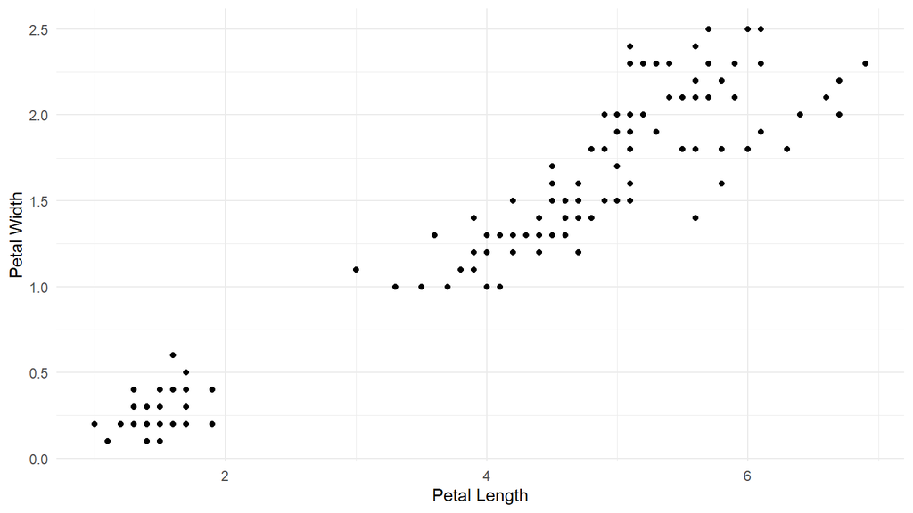

## Lineare Regression

```r
linear_model <- lm(Petal.Width ~ Petal.Length, data = iris)

summary(linear_model)
```

```
Call:
lm(formula = Petal.Width ~ Petal.Length, data = iris)

Residuals:
     Min       1Q   Median       3Q      Max
-0.56515 -0.12358 -0.01898  0.13288  0.64272

Coefficients:
              Estimate Std. Error t value Pr(>|t|)
(Intercept)  -0.363076   0.039762  -9.131  4.7e-16 ***
Petal.Length  0.415755   0.009582  43.387  < 2e-16 ***
---
Signif. codes:  0 '***' 0.001 '**' 0.01 '*' 0.05 '.' 0.1 ' ' 1

Residual standard error: 0.2065 on 148 degrees of freedom
Multiple R-squared:  0.9271,    Adjusted R-squared:  0.9266
F-statistic:  1882 on 1 and 148 DF,  p-value: < 2.2e-16
```

## Lineare Regression

```r
library(mgcv)
```

```r
linear_model_gam <- gam(Petal.Width ~ Petal.Length,
                        family = gaussian(),
                        data = iris)
summary(linear_model_gam)
```

```
Family: gaussian
Link function: identity

Formula:
Petal.Width ~ Petal.Length

Parametric coefficients:
              Estimate Std. Error t value Pr(>|t|)
(Intercept)  -0.363076   0.039762  -9.131  4.7e-16 ***
Petal.Length  0.415755   0.009582  43.387  < 2e-16 ***
---
Signif. codes:  0 '***' 0.001 '**' 0.01 '*' 0.05 '.' 0.1 ' ' 1


R-sq.(adj) =  0.927   Deviance explained = 92.7%
GCV = 0.043212  Scale est. = 0.042636  n = 150
```

## Lineare Regression

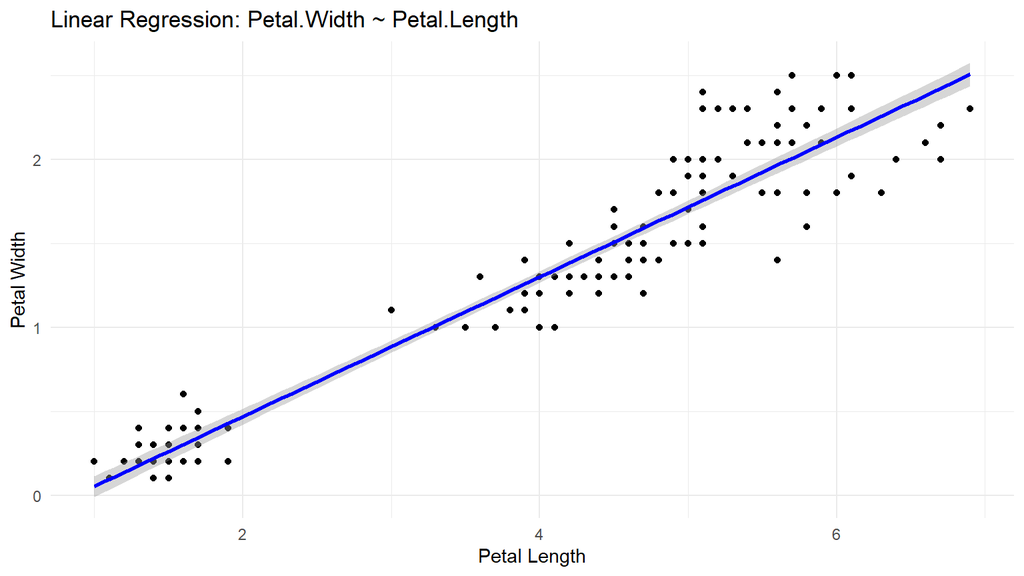

## Linear Mixed Models

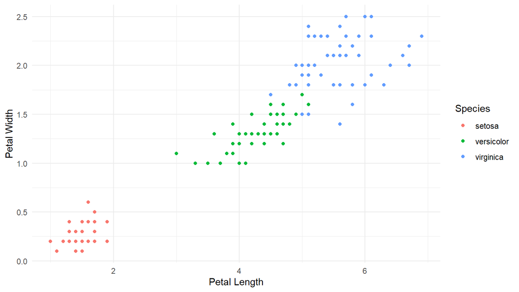

## Fixed Effects Linear Model

```r
fixed_effects_model <- gam(Petal.Width ~ Petal.Length + Species,
                           family = gaussian(),
                           data = iris)
summary(fixed_effects_model)
```

```
Family: gaussian
Link function: identity

Formula:
Petal.Width ~ Petal.Length + Species

Parametric coefficients:
                  Estimate Std. Error t value Pr(>|t|)
(Intercept)       -0.09083    0.05639  -1.611    0.109
Petal.Length       0.23039    0.03443   6.691 4.41e-10 ***
Speciesversicolor  0.43537    0.10282   4.234 4.04e-05 ***
Speciesvirginica   0.83771    0.14533   5.764 4.71e-08 ***
---
Signif. codes:  0 '***' 0.001 '**' 0.01 '*' 0.05 '.' 0.1 ' ' 1


R-sq.(adj) =  0.944   Deviance explained = 94.6%
GCV = 0.033156  Scale est. = 0.032272  n = 150
```

## Linear Mixed Model

Random Effects sind insbesondere dann sinnvoll, wenn davon auszugehen ist, dass eine Variable aufgrund hierarchischer Strukturen stark mit anderen Variablen korreliert (z.B. wenn Gruppen starke Unterschiede in der Variablenausprägung aufweisen)

```r
random_effects_model <- gam(Petal.Width ~ Petal.Length +
                              s(Species, bs  = "re"),
                            family = gaussian(),
                            data = iris)
summary(random_effects_model)
```

```
Family: gaussian
Link function: identity

Formula:
Petal.Width ~ Petal.Length + s(Species, bs = "re")

Parametric coefficients:
             Estimate Std. Error t value Pr(>|t|)
(Intercept)   0.30931    0.34392   0.899     0.37
Petal.Length  0.23683    0.03386   6.994  8.9e-11 ***
---
Signif. codes:  0 '***' 0.001 '**' 0.01 '*' 0.05 '.' 0.1 ' ' 1

Approximate significance of smooth terms:
             edf Ref.df     F p-value
s(Species) 1.963      2 24.21  <2e-16 ***
---
Signif. codes:  0 '***' 0.001 '**' 0.01 '*' 0.05 '.' 0.1 ' ' 1

R-sq.(adj) =  0.944   Deviance explained = 94.6%
GCV = 0.033147  Scale est. = 0.032272  n = 150
```

## Linear Mixed Model

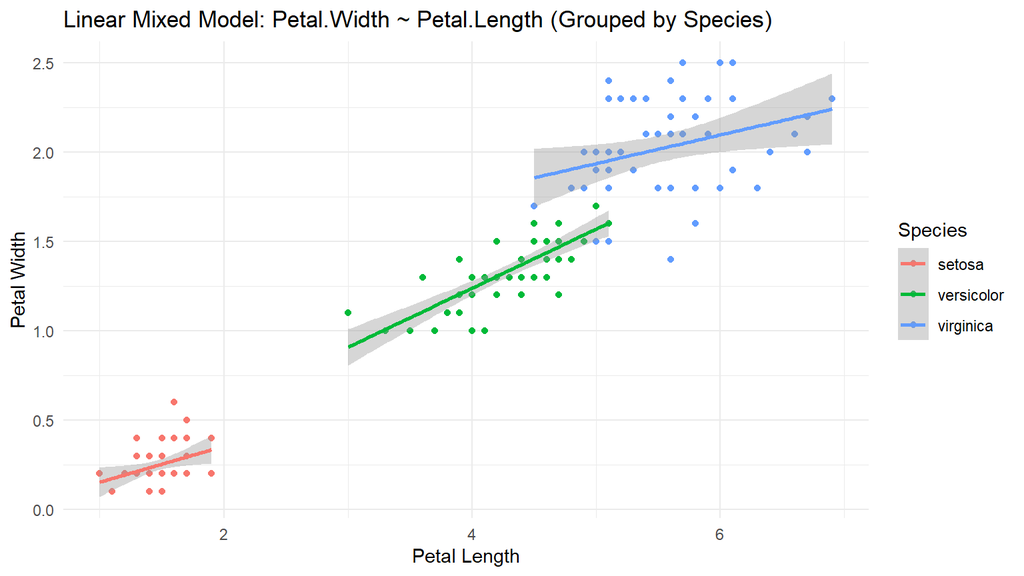

## Generalized Linear Model

Wenn wir keine normalverteile Grundgesamtheit haben, brauchen wir ein Modell, das dies berücksichtig. Z.B. wenn wir es mit binären Variablen zutun haben:

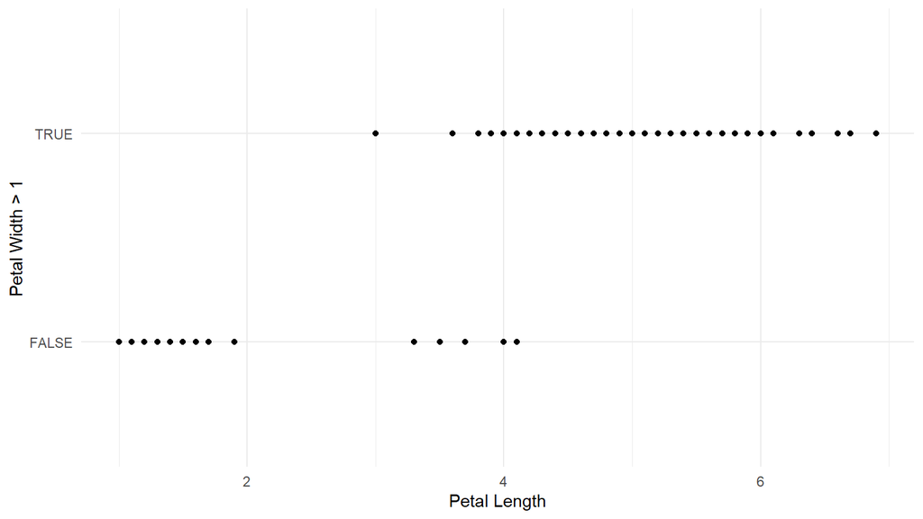

## Generalized Linear Model

```r
generalized_model <- gam(Petal.Width.Binary ~ Petal.Length,
                            family = binomial(),
                            data = iris)

summary(generalized_model)
```

```
Family: binomial
Link function: logit

Formula:
Petal.Width.Binary ~ Petal.Length

Parametric coefficients:
             Estimate Std. Error z value Pr(>|z|)
(Intercept)   -15.158      5.011  -3.025  0.00249 **
Petal.Length    4.247      1.292   3.287  0.00101 **
---
Signif. codes:  0 '***' 0.001 '**' 0.01 '*' 0.05 '.' 0.1 ' ' 1


R-sq.(adj) =  0.891   Deviance explained = 87.3%
UBRE = -0.80415  Scale est. = 1         n = 150
```

## Generalized Additive Model (GAM)

- erlaubt unterschiedliche Verteilungen außerhalb der Normalverteilung
- erlaubt Random Effects
- erlaubt neben Random Effects auch die Modellierung von Variablen als Splines, d.h. als nicht-linearen Zusammenhang

## Generalized Additive Model (GAM)

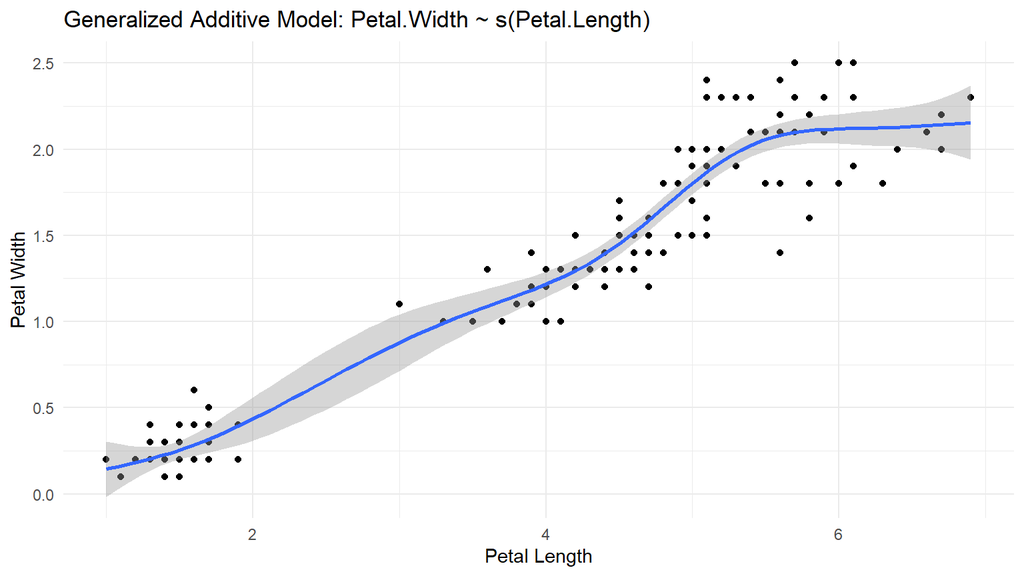

## Generalized Additive Model (GAM)

```r
gam <- gam(Petal.Length ~ s(Petal.Width),
           family = gaussian(),
           data = iris)

summary(gam)
```

```
Family: gaussian
Link function: identity

Formula:
Petal.Length ~ s(Petal.Width)

Parametric coefficients:
            Estimate Std. Error t value Pr(>|t|)
(Intercept)  3.75800    0.03102   121.2   <2e-16 ***
---
Signif. codes:  0 '***' 0.001 '**' 0.01 '*' 0.05 '.' 0.1 ' ' 1

Approximate significance of smooth terms:
                 edf Ref.df   F p-value
s(Petal.Width) 5.562  6.687 459  <2e-16 ***
---
Signif. codes:  0 '***' 0.001 '**' 0.01 '*' 0.05 '.' 0.1 ' ' 1

R-sq.(adj) =  0.954   Deviance explained = 95.5%
GCV = 0.15093  Scale est. = 0.14433   n = 150
```

## Generalized Additive Model (GAM)

```r
gam_2 <- gam(Petal.Length ~ s(Petal.Width) + Species,
             family = gaussian(),
             data = iris)

summary(gam_2)
```

```
Family: gaussian
Link function: identity

Formula:
Petal.Length ~ s(Petal.Width) + Species

Parametric coefficients:
                  Estimate Std. Error t value Pr(>|t|)
(Intercept)         2.6879     0.2735   9.827  < 2e-16 ***
Speciesversicolor   1.3434     0.3964   3.389 0.000907 ***
Speciesvirginica    1.8669     0.4315   4.327 2.82e-05 ***
---
Signif. codes:  0 '***' 0.001 '**' 0.01 '*' 0.05 '.' 0.1 ' ' 1

Approximate significance of smooth terms:
                 edf Ref.df     F p-value
s(Petal.Width) 3.696  4.584 12.65  <2e-16 ***
---
Signif. codes:  0 '***' 0.001 '**' 0.01 '*' 0.05 '.' 0.1 ' ' 1

R-sq.(adj) =  0.958   Deviance explained = 95.9%
GCV = 0.13801  Scale est. = 0.13185   n = 150
```

## Generalized Additive Model (GAM)

```r
species_model <- gam(Petal.Length ~ Petal.Width + Species,
                     family = gaussian(),
                     data = iris)

anova(species_model, gam_2)
```

```
Analysis of Deviance Table

Model 1: Petal.Length ~ Petal.Width + Species
Model 2: Petal.Length ~ s(Petal.Width) + Species
  Resid. Df Resid. Dev     Df Deviance
1    146.00     20.833
2    142.42     18.894 3.5837   1.9394
```

## Generalized Additive Model (GAM)

Ressourcen zu GAMs:

- Zugängliche Einführung zu den Vorteilen von GAMs: https://m-clark.github.io/generalized-additive-models/
- Vollständige Übersicht über GAMs und andere Modelle: Wood, Simon. 2017. Generalized Additive Models: An Introduction with R. https://doi.org/10.1201/9781315370279.

## Weitere Regressionsmodelle und Tools

- *marginaleffects*-Package: erlaubt die Berechnung von Grenzeffekten, was die Interpretation von Modellen deutlich verbessern kann (insb. auch bei GAMs) - mit zugänglicher Einführung: https://marginaleffects.com/
- *brms*-Package: erlaubt die Berechnung von Bayes-Modellen mit MCMC. Das dafür benötigte STAN ist auf dem Server installiert